# Quantum Phase Estimation

Quantum phase estimation is one of the foundational quantum algorithms. It makes use of the quantum Fourier transform as a subroutine. Many quantum algorithms build upon it as a core component, and in certain structured cases, such as Shor's factoring algorithm, it enables exponential speedups over known classical methods.

In this tutorial, we will describe the problem that the quantum phase estimation algorithm aims to solve and the tools it employs to do so. We will show that to estimate a phase with a target precision $\epsilon$, the complexity of the algorithm is dominated by $\mathcal{O} \left(\frac{1}{\epsilon}\right)$. While the total resource cost can also be expressed in terms of the number of qubits, gate depth, or oracle queries, the precision parameter $\epsilon$ is the determinant factor that governs the overall scaling.

Finally, we will implement an instance of the quantum phase estimation algorithm using PennyLane and conclude with remarks comparing its performance and scaling behvaiour with classical techniques.

1. Introduction
2. Phase Estimation Problem
3. The One-Qubit QPE
4. Two-Qubit Phase Estimation
5. $t$-qubit Phase Estimation
6. Error Analysis
7. Example: Estimating a Phase with QPE
8. Conclusion

### Appendices

9. Appendix 1: Biography
10. Appendix 2: References and Suggested Readings

### Introduction

A unitary $U \in \mathbb{C}^{2^n} \times \mathbb{C}^{2^n}$ has $2^n$ eigenvalues counted with algebraic multiplicity, and each has modulus 1. The multiset of these $2^n$ eigenvalues (including multiplicities) is uniquely determined by $U$. However, the egienbasis (the basis made up of the eignvalues) is not unique. Indeed, there are infinitely many choices of eigenbasis for a given unitary $U$.

**Example**. The eigenvalues of $X = \begin{bmatrix} 0 & 1 \\ 1 & 0 \end{bmatrix}$ are $+1$ and $-1$. Its eigenbases include $\{ |+\rangle, |-\rangle \}, \{ -|+\rangle, e^{\frac{i \pi}{2}} |-\rangle \}$, and more generally, $\{ e^{i \alpha} |+\rangle, e^{i \beta} |-\rangle \}$ for any choice of $\alpha, \beta \in \mathbb{R}$.

While the spectral theorem is not strictly necessary for the development of quantum phase estimation, it provides useful motivation, which we introduce here. Note that the spectral theorem has several variants depending on the mathematical setting, for example, finite-dimensional spaces or $C^*$-algebras. In this section, we focus on the finite-dimensional complex case.

To state the theorem, we first need to familiarize ourselves with normal matrices. A square complex matrix $N$ is normal if it commutes with its conjugate transpose $N^\dagger$, that is $$ NN^\dagger = N^\dagger N. $$

Unitary matrices $U$ are normal, since $UU^\dagger = I = U^\dagger U$. Other important families of normal matrices include Hermitian matrices, which satisfy $H = H^\dagger$. While Hermitian and unitary matrices are not the same, they are closely connected—for example, the exponential of a Hermitian matrix is unitary.

**Spectral Theorem.**

Given an $n \times n$ normal matrix $N$, there exists an orthonormal eigenbasis $\{ |\psi_1 \rangle, \dots, |\psi_n \rangle \}$ of $\mathbb{C}^n$ along with eigenvalues $\lambda_1, \dots, \lambda_n$ such that $$ N = \lambda_1 | \psi_1 \rangle \langle \psi_1 | + \dots + \lambda_n | \psi_n \rangle \langle \psi_n | = \sum\limits_{k=1}^n \lambda_k | \psi_k \rangle \langle \psi_k |. $$

By the spectral theorem and the fact that a unitary $U$ is a normal matrix, if we are given $U$ along with one of its eigenstates $|\psi\rangle$, then determining the corresponding eigenvalue $\lambda$ can reveal important information. For example, this underlies Shor's algorithm for finding the order of an element $a \pmod{N}$, as well as algorithms in quantum chemistry for estimating molecular energies. While such applications are important and interesting, the focus of this tutorial is limited to introducing quantum phase estimation (QPE). We will state QPE formally next. Note that it is expressed as a *promise problem*: we are given both the unitary $U$ and one of its eigenstates $|\psi\rangle$.

**Phase Estimation Problem**

Given an $n$-qubit unitary $U$ and an eigenstate $|\psi\rangle$ of $U$, determine the corresponding eigenvalue $\lambda = e^{2\pi i \theta}$ for some $\theta \in [0,1)$.

Note that the QPE algorithm returns the digits of $\theta = 0.\theta_1 \theta_2 \dots$ in binary. An $m$-digit binary fraction $d = 0.d_1 d_2 \dots d_m$ represents $$ d = \sum\limits_{k=1}^m d_k 2^{-k}. $$

In general, $\theta$ does not have a finite binary expansion; most numbers have infinite expansions in any base. What ultimately matters is the desired level of precision: even though $\theta$ may expand infinitely, in practice we are satisfied with only a finite number of digits after the radix point <sup>[1]</sup>. Indeed, the set of numbers with finite binary expansionis measure zero, while those with infinite expansion form a measure-one set.

Another important consideration is how binary precision compares to decimal precision. To match the accuracy of one decimal digit, we require $n$ binary digits such that

$$ \frac{1}{2^n} \leq \frac{1}{10} \Rightarrow 2^n \geq 10 \Rightarrow n \geq \log_2 (10) \approx 3.32. $$

Thus, at least 4 binary digits are needed to guarantee precision comparable to 1 decimal digit. This becomes especially relevant in the context of QPE, since the algorithm is resource-intensive and each additional binary digit requires more work. The following table shows how many binary digits are needed to guarantee the same or better accuracy as a given number of decimal digits:

| Decimal digits ($\approx 10^{-d}$) | Required binary digits $n \approx \lceil d \log_2 10 \rceil$ |
| --- | --- |
| 1 digit ($\sim 0.1$) | 4 bits |
| 2 digits ($\sim 0.01$) | 7 bits |
| 3 digits ($\sim 0.001$) | 10 bits |
| 4 digits ($\sim 0.0001$) | 14 bits |
| 5 digits ($\sim 0.00001$) | 17 bits |

As we will see, achieving higher precision requires access to higher powers of the unitary. While the algorithm assumes that $U^{2^k}$ is readily available, in practice implementing these powers can be costly in general. For specific applications where $U$ has a special structure, such as in Shor’s algorithm, preparing $U^{2^k}$ can be done more efficiently, although Shor’s algorithm also demands very high precision and therefore deep quantum circuits.

### The One-Qubit QPE

We will begin by discussing QPE in a low-precision setting to build intuition, and then extend to the general case of arbitrary precision.

For the one-bit case, the QPE circuit starts with the state $|0\rangle|\psi\rangle$. A Hadamard gate is applied to the first qubit, creating an equal superposition. This enables the subsequent controlled-$U$ to imprint the eigenphase onto the control qubit via phase kickback. Finally, a second Hadamard is applied to the first qubit, which interferes the amplitudes in a way that encodes information about the phase $\theta$ into the measurement probabilities of $|0\rangle$ and $|1\rangle$.

The circuit is visualized in the figure below.

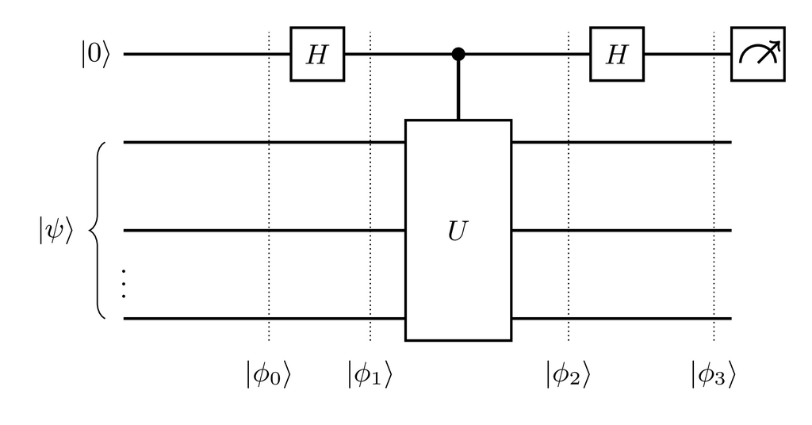

The input state is $$ | \phi_{0} \rangle = |0\rangle |\psi \rangle $$ where $\psi$ is an eigenstate of $U$.

A Hadamard gate is applied to the first wire transforming the state to $$ |\phi_{1} \rangle = |+\rangle |\psi \rangle = \frac{1}{\sqrt{2}} \left( |0\rangle |\psi\rangle + |1\rangle |\psi \rangle \right) $$

Next, we apply the controlled-$U$ on the $n+1$ qubit system, using $|1\rangle$ on the first wire as the control and $|\psi\rangle$ as the target. In this case, $U$ acts on $|\psi\rangle$. This yields the following state:

$$ | \phi_{2} \rangle = \frac{1}{\sqrt{2}} \left( |0 \rangle |\psi \rangle + |1\rangle U | \psi \rangle \right) = \frac{1}{\sqrt{2}} \left( |0 \rangle |\psi \rangle + e^{2\pi i \theta} |1\rangle | \psi \rangle \right) $$

where in the last equality we used that $|\psi\rangle$ is an eigenstate of $U$ with eigenvalue $\lambda = e^{2\pi i\theta}$. This property is an imporant component to the design of QPE, as it enables phase kickback onto the control wire.

Subsequently, we apply a Hadamard gate on the first wire so that information about $\theta$ can be extracted through measurement. This yields the following state before measurement:

$$ \begin{aligned} | \phi_3 \rangle &= \frac{1}{2} \left[ |0\rangle + |1\rangle + e^{2 \pi i \theta} |0\rangle - e^{2 \pi i \theta} |1\rangle \right] \otimes | \psi \rangle \\ &= \left[ \frac{1 + e^{2 \pi i \theta}}{2} |0 \rangle + \frac{1 - e^{2 \pi i \theta}}{2} |1 \rangle \right] \otimes | \psi \rangle \end{aligned} $$

Next, before measurement, we simplify the coefficients on the first wire.

Note that from Euler's identity $e^{i \theta} = \cos(\theta) + i \sin(\theta)$, we have $$ \begin{aligned} & \cos(\theta) = \frac{e^{i \theta} + e^{- i \theta}}{2} \\ \Rightarrow & 2 \cos(\theta) = e^{i \theta} + e^{- i \theta} \\ \Rightarrow & \frac{2 \cos(\theta)}{e^{- i \theta}} = \frac{e^{i \theta}}{e^{- i \theta}} + \frac{e^{- i \theta}}{e^{- i \theta}} \\ \Rightarrow & 2 \cos(\theta) e^{i \theta} = e^{2 i \theta} + 1 \\ \Rightarrow & \cos(\theta) e^{i \theta} = \frac{1 + e^{2 i \theta}}{2} \end{aligned} $$

By similar reasoning and using the equality $\sin(\theta) = \frac{e^{i \theta} - e^{-i \theta}}{2i}$, it follows that $\frac{1 - e^{2 \pi i \theta}}{2} = -i \sin(\theta) e^{i \theta}$.

Hence, the state $|\phi_{3} \rangle$ can be re-written as: $$ |\phi_3 \rangle = \left[ e^{\pi i \theta} \cos(\pi \theta) |0\rangle - i e^{\pi i \theta} \sin(\pi \theta) |1 \rangle \right] \otimes | \psi \rangle. $$

Measuring the first wire in the computational basis yields the probabilities $$ \begin{aligned} p(0) &= \cos^2(\pi\theta), \\ p(1) &= \sin^2(\pi\theta), \end{aligned} $$ where $p(0)$ and $p(1)$ denote the probability of obtaining outcome $0$ and outcome $1$ on the first wire, respectively.

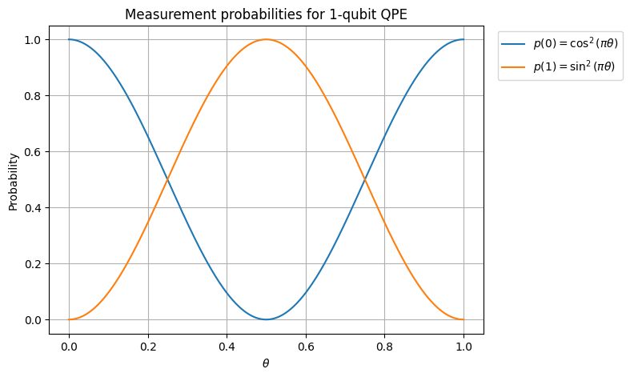

```python
import numpy as np
import matplotlib.pyplot as plt

theta = np.linspace(0,1,500)
# Probabilities for 1 ancilla qubit QPE
p0 = np.cos(np.pi * theta)**2
p1 = np.sin(np.pi * theta)**2

# Plot
plt.figure(figsize=(7,5))
plt.plot(theta, p0, label=r"$p(0) = \cos^2(\pi\theta)$")
plt.plot(theta, p1, label=r"$p(1) = \sin^2(\pi\theta)$")
plt.title("Measurement probabilities for 1-qubit QPE")
plt.xlabel(r"$\theta$")
plt.ylabel("Probability")
plt.legend(loc="upper left", bbox_to_anchor=(1.02, 1.0))
plt.grid(True)
plt.show()
```

$\DeclareMathOperator{\QFT}{QFT}$

#### Interpretation of QPE output (with 1 bit precision)

With $t$ ancilla qubits, QPE produces a measurement outcome $m \in \{0,1,\dots,2^t-1\}$, which is interpreted as the estimate

$$ \hat{\theta} = \frac{m}{2^t}. $$

Thus, the possible outcomes lie on a $2^t$-point grid in the unit interval $[0,1)$. The probability distribution is sharply peaked at the grid point closest (modulo 1) to the true phase $\theta$.

#### The 1-bit case ($t=1$)

- The grid has just two points: $\{0, 0.5\}$.
- If $\theta$ is near 0 or 1 (wrap-around), the algorithm favors outcome 0.
- If $\theta$ is near 0.5, the algorithm favors outcome 0.5.
- Example: for $\theta = 0.82_{10} \approx 0.1101000111101011\ldots_2$, the QPE algorithm is more likely to return $0$ than $0.5$, since $\cos^2(0.82\pi) \approx 0.71$ and $\sin^2(0.82\pi) \approx 0.29$, even though the first binary digit of $0.82$ is $1$. On the other hand, if $\theta = \tfrac{1}{2}$, then QPE returns $1$ with probability $1$, which matches the correct binary expansion $0.5_{10} = 0.1_2$.

As we will argue, to recover the first $n$ binary digits with high probability, QPE requires $t = n+1$ ancilla qubits. This corresponds to one notion of success probability. We will also discuss alternative bounds expressed in terms of the distance between the estimate and the true phase.

Before moving to the two-qubit phase estimation, it is worth noting that in the one-qubit case the Hadamard basis coincides with the two-dimensional quantum Fourier basis. In other words, the Hadamard gate is $\QFT_2$. Moreover, since $H^\dagger = H$, it follows that $\QFT_2 = \QFT_2^\dagger$. This observation becomes relevant as we generalize phase estimation to the $n$-qubit case, where the full inverse QFT plays a central role.

### Two-Qubit Phase Estimation

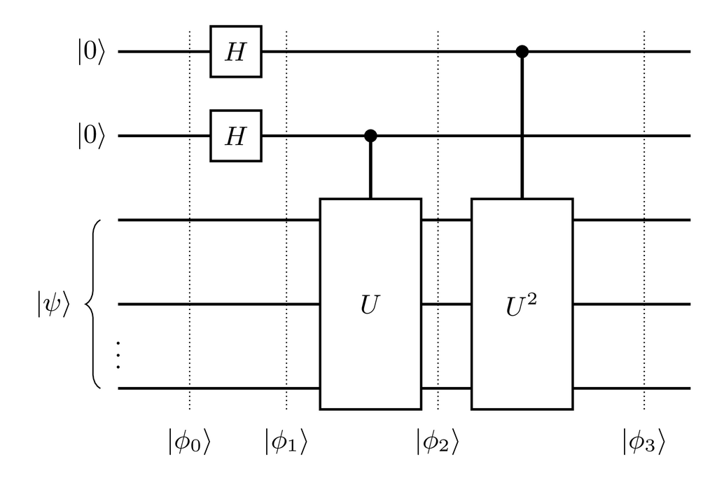

Similar to the 1-qubit QPE, we have $$|\phi_{0} \rangle = |0\rangle^{\otimes 2} |\psi \rangle$$ as the input state.

Then we will apply Hadamards on each of the wires yielding $$ |\phi_{1} \rangle = \frac{1}{2} \sum\limits_{b_0 = 0}^{1} \sum\limits_{b_1=0}^1 |b_1 b_0 \rangle |\psi \rangle $$

We continue with applying controlled-$U$ with the second wire acting as the control, yielding: $$ | \phi_{2} \rangle = \frac{1}{2} \sum\limits_{b_0 = 0}^{1} \sum\limits_{b_1=0}^1 |b_1 b_0 \rangle U^{b_1} |\psi \rangle $$

Similarly, applying controlled-$U^2$ gives: $$ | \phi_{3} \rangle = \frac{1}{2} \sum\limits_{b_0 = 0}^{1} \sum\limits_{b_1=0}^1 |b_0 b_1 \rangle U^{2 b_0+b_1} |\psi \rangle $$

Noting that the eigenvalue of $U$ is $\lambda = e^{2 \pi i \theta}$, it follows that $U^{2 b_0 + b_1} |\psi \rangle = e^{2 \pi i \theta (2 b_0 + b_1)} |\psi \rangle$, therefore, $$ | \phi_{3} \rangle = \frac{1}{2} \sum\limits_{b_0 = 0}^{1} \sum\limits_{b_1=0}^1 |b_0 b_1 \rangle e^{2 \pi i \theta (2 b_0 + b_1)} |\psi \rangle, $$ and expanding the summations yields, $$ | \phi_{3} \rangle = \frac{1}{2} \left[ |00 \rangle + e^{2 \pi i \theta} |01 \rangle + e^{4 \pi i \theta} |10 \rangle + e^{6 \pi i \theta} |11\rangle \right] \otimes | \psi \rangle $$

Note that measuring the ancilla register at this point, which is in an equal superposition with amplitude $\frac{1}{2}$, would yield each two-bit computational basis state with equal probability $\frac{1}{4}$, regardless of the different relative phases. Therefore, we need a method to convert the relative phase information into measurable amplitude information.

To better understand the required transformation, let's assume $\theta$ is exactly a multiple of $\frac{1}{4}$. Recall, in practice $0 \leq \theta < 1$, but this special case motivates the transformation nicesly. Hence, $$ \theta \in \left\{ 0, \frac{1}{4}, \frac{2}{4}, \frac{3}{4} \right\}. $$

Let $|\phi_3 \rangle = | v(\theta) \rangle = \frac{1}{2} \sum\limits_{k=0}^{3} e^{2 \pi i \theta k} | k \rangle$

For those values, the state becomes:

- $\theta = 0$: $$ |v(0) \rangle = \frac{1}{2} \left( |00 \rangle + |01 \rangle + |10 \rangle + |11 \rangle \right). $$
- $\theta = \frac{1}{4}$: $$ \left| v \left(\frac{1}{4} \right) \right\rangle = \frac{1}{2} \left( |00 \rangle + i |01 \rangle - |10 \rangle -i |11 \rangle \right). $$
- $\theta = \frac{2}{4}$: $$ \left| v \left(\frac{2}{4} \right) \right\rangle = \frac{1}{2} \left( |00 \rangle - |01 \rangle + |10 \rangle - |11 \rangle \right). $$
- $\theta = \frac{3}{4}$: $$ \left| v \left(\frac{3}{4} \right) \right\rangle = \frac{1}{2} \left( |00 \rangle -i |01 \rangle - |10 \rangle +i |11 \rangle \right). $$

These states form an orthnormal basis:

**Proof**

We have the four states $$ \left| v \left( \frac{m}{4} \right) \right\rangle = \frac{1}{2} \sum\limits_{k=0}^3 e^{2 \pi i \left( \frac{m}{4} \right) k} | k \rangle, \quad m = 0,1,2,3. $$

To check orthnormality, we will compute the inner product of $m_0$ and $m_1$: $$ \begin{aligned} \left\langle v \left( \frac{m_0}{4} \right) | v \left( \frac{m_1}{4} \right) \right\rangle &= \frac{1}{4} \sum\limits_{k=0}^3 e^{- 2 \pi i \frac{m_0}{4} k} e^{2 \pi i \frac{m_1}{4} k} \\ &= \frac{1}{4} \sum\limits_{k=0}^3 e^{2 \pi i k \frac{(m_0 - m_1)}{4}} \end{aligned} $$

Depending whether $m_0 = m_1$ or $m_0 \neq m_1$, there are two cases:

1. $m_0 = m_1 \Rightarrow m_0 - m_1 = 0$, then each exponential is $1$, so the sum is $4$, giving inner product $=1$.
2. $m_0 \neq m_1$, then this is a finite geometric series:

$$ \frac{1}{4} \cdot \frac{1 - e^{2 \pi i (m_0 - m_1)}}{1 - e^{2 \pi i \frac{m_0 - m_1}{ 4 } }} = \frac{1}{4} \cdot \frac{1 - 1}{1 - 2^{\pi i \frac{m_0 - m_1}{4}}} = 0 $$

Note that $m_0 - m_1$ is always a non zero integer in this case, which implies $e^{2 \pi i \frac{m_0 - m_1}{4}} \neq 1$, so the denominator does not vanish.

This shows the four states are orthonormal, as expected.

Now to get the desired output, we wish to transform $\left| v\left( \frac{m}{4} \right) \right \rangle \mapsto m$ so that when a measurement is perfromed in the computational basis, we measure $m$. At this point, we do not know if such a unitary exists that enables the transformation $\left| v\left( \frac{m}{4} \right) \right \rangle \mapsto m$. However, this is why showing $\left\{ \left| v\left( \frac{m}{4} \right) \right\rangle | m \in \{ 0,1,2,3 \} \right\}$ is an orthonormal basis is relevant alongside the fact that we want to map to another orthonormal basis. The follwoing theorem shows that there is always exists a unitary that maps two orthonormal bases and provides a way to construct such unitary:

**Theorem - Unitary Mapping between Orthonormal Bases**

Let $\mathcal{H}$ be a finite dimensional Hilbert space. Let $\{ | a_j \rangle \}_{j \in \mathcal{J}}$ and $\{ |b_j \rangle \}_{j \in \mathcal{J}}$ be two orthonormal bases of $\mathcal{H}$, with the same index set $\mathcal{J}$. Then there exists a unique operator $U: \mathcal{H} \rightarrow \mathcal{H}$ such that $$ U | a_j \rangle = |b_j \rangle \quad \forall j \in \mathcal{J} $$

Moreover $U$ is given explicitly by: $$ U = \sum\limits_{j \in J} | b_j \rangle \langle a_j |. $$

**Proof** *(click to expand / collapse)**

Let $\dim \mathcal{H} = n$. Define $$ U = \sum\limits_{j=1}^n |b_j \rangle \langle a_j |. $$

1. **Action on the basis**

Next, we want to show for a fixed $k \in \{ 1, \dots, n \}$, we have $U | a_k \rangle = |b_k \rangle$. So fix such a $k$. Then,

$$ \begin{aligned} U | a_k \rangle &= \sum\limits_{j=1}^{n} | b_j \rangle \langle a_j | a_k \rangle \qquad &&(\text{Definition of $U$}) \\ &= \sum\limits_{j=1}^n |b_j \rangle \delta_{jk} &&(\text{Orthonormality of $\{ a_j \}_{j \in \mathcal{J}}$}) \\ &= | b_k \rangle && (\text{Since $\delta_{jk} = 1$ when $j = k$ and $0$ otherwise}) \end{aligned} $$

2. **Unitary**

We want to show $U$ is a unitary. That is $U^\dagger U = I = UU^\dagger$. Given that $U = \sum\limits_{j=1}^n |b_j \rangle \langle a_j |$, it follows that $U^\dagger = \sum\limits_{j=1}^n |a_j \rangle \langle b_j |$. Then

$$ U^\dagger U = \sum\limits_{j,k} | a_j \rangle \langle b_j | b_k \rangle \langle a_k | = \sum\limits_{k} |a_k \rangle \langle a_k | = I, $$

because $\langle b_j | b_k \rangle = \delta_{jk}$ and $\sum\limits_{k} | a_k \rangle \langle a_k | = I$.

By similar reasoning, it follows that $UU^\dagger = I$. Therefore $U$ is unitary.

3. **Uniqueness.**

We want to show $U$ is the unique operator with this property. Suppose $V$ is any linear operator such that $V|a_j \rangle = |b_j \rangle$ for all $j$, then $V=U$. So $V$ is a linear operator with $V | a_j \rangle = |b_j \rangle$ for all $j$.

For any vector $|\psi \rangle = \sum\limits_{j} \alpha_j | a_j \rangle $, linearity gives

$$ V | \psi \rangle = V \left( \sum\limits_{j} \alpha_j | a_j \rangle \right) = \sum\limits_{j} \alpha_j V | a_j \rangle = \sum\limits_{j} \alpha_j |b_j \rangle. $$

But this is exactly what $U$ does:

$$ U |\psi \rangle = \sum\limits_{j} \alpha_j | b_j \rangle. $$

Thus $V |\psi \rangle = U | \psi \rangle $ for every $| \psi \rangle$, and therefore $V = U$.

Applying the existence of unitary mapping between orthonormal bases to our context implies the following useful corollary.

**Corollary** There exsits a unique unitary $U$ such that: $$ U \left| v \left( \frac{m}{4} \right) \right\rangle = |m \rangle \quad \forall m $$ By explicit construction in the theorem, this unitary is $$ U = \sum\limits_{m = 0}^{3} |m \rangle \left\langle v\left( \frac{m}{4} \right) \right| $$

Note that we are labelling the computational basis states as $| 0 \rangle = | 00 \rangle$, $|1\rangle = |01 \rangle$, $| 2 \rangle = |10 \rangle $, $|3\rangle = |11 \rangle$.

Next we will prove another theorem that aids with reading off the entries of the unitary $U$, that maps one orthornormal basis $\mathcal{A}$ (e.g. the $\left| v \left( \frac{m}{4} \right) \right \rangle$) to another orthonormal basis $\mathcal{B}$ (e.g. the computational basis).

**Theorem.**

Let $\mathcal{H}$ be an $n$-dimensional Hilbert space. Let $$ \mathcal{A} = \{ |a_0 \rangle, \ldots, |a_{n-1} \rangle \}, \qquad \mathcal{B} = \{ | b_0 \rangle, \ldots, | b_{n-1} \rangle \} $$ be orthonormal bases of $\mathcal{H}$.

Define the unitary matrix $$ U = \sum\limits_{m = 0}^{n-1} | b_m \rangle \langle a_m |, $$ so that $U|a_m \rangle = |b_m \rangle $ for all $m$.

Then the matrix of $U$ in the $\mathcal{B}$-basis has entries $$ [U]_{\mathcal{B}}(j,k) = \langle b_j | U | b_k \rangle = \langle a_j | b_k \rangle \quad (0 \leq j,k < n) $$ Equivalently, the $k$-th column of $[U]_{\mathcal{B}}$ is $$ \begin{bmatrix} \langle a_0 | b_k \rangle \\ \vdots \\ \langle a_{n -1} | b_k \rangle \end{bmatrix}. $$

**Proof** *(click to expand / collapse)**

The matrix of $U$ in the $\mathcal{B}$-basis is defined by:

$$ [U]_{\mathcal{B}}(j,k) \coloneqq \langle b_j | U | b_k \rangle $$

To see why this definition makes sense, note that for any fixed $k$, applying $U$ to a basis vector $|b_{k} \rangle$ gives another vector in $\mathcal{H}$: $$ U | b_k \rangle \in \mathcal{H} $$

Since $\{ | b_j \rangle \}$ is a basis of $\mathcal{H}$, we can expand this vector uniquely as

$$ U | b_k \rangle = \sum\limits_{j=0}^{n-1} M_{j,k} |b_j \rangle. $$

Note that here we are treating $U$ as the abstract operator, which is a linear map $U: \mathcal{H} \rightarrow \mathcal{H}$, whose definition is basis-independent, while $M = [U]_{\mathcal{B}}$ is the matrix representation of $U$ in the chosen basis, $\mathcal{B}$. Different bases give different matrices for the same operator, but they all represent the same underlying action of $U$.

To extract the coefficient given by $M_{j,k}$, fix $\ell \in \{ 0,1,\ldots, n-1 \}$, and take the inner product $\langle b_\ell | \left( U | b_k \rangle \right)$:

$$ \begin{aligned} \langle b_\ell | \left( U |b_{k} \rangle \right) &= \sum\limits_{j=0}^{n-1} M_{j,k} \langle b_{\ell} | b_j \rangle \\ &= \sum\limits_{j=0}^{n-1} M_{j,k} \delta_{\ell, j} \\ &= M_{\ell, k} \end{aligned} $$

Hence, each entry of the matrix is given by $M_{j,k} = \langle b_j | U | b_{k} \rangle$. So the $(j,k)$-entry records how much of $|b_{j} \rangle$ appears in $U |b_{k} \rangle$.

Noting that $U = \sum\limits_{m=0}^{n-1} | b_m \rangle \langle a_m |$, it follows that $$ \begin{aligned} \langle b_j | U | b_k \rangle &= \langle b_j | \underbrace{\left( \sum\limits_{m} | b_m \rangle \langle a_m \right)}_{= U} | b_k \rangle \\ &= \sum\limits_{m} \langle b_j | b_m \rangle \langle a_m | b_k \rangle \\ &= \underbrace{\langle b_j | b_j \rangle}_{= 1} \langle a_j | b_k \rangle \\ &= \langle a_j | b_k \rangle. \end{aligned} $$

Thus, $$ [U]_{\mathcal{B}}(j,k) = \langle a_j | b_k \rangle. $$

Fix $k$. Then column $k$ of $[U]_{\mathcal{B}}$ is the vector $$ \begin{bmatrix} \langle a_0 | b_k \rangle \\ \langle a_1 | b_k \rangle \\ \vdots \\ \langle a_{n-1} | b_k \rangle \end{bmatrix}. $$

**Corollary**. Take $\mathcal{A} = \left\{ \left| v\left( \frac{j}{4} \right) \right\rangle \right\}_{j=0}^3$ and $\mathcal{B} = \{ |k\rangle \}_{k=0}^3$. By the above theorem, $$[U]_{\text{computational basis}}(j,k) \coloneqq U(j,k) = \left\langle v \left( \frac{j}{4} \right) | k \right\rangle.$$

Recall $$ \left| v \left( \frac{m}{4} \right) \right\rangle = \frac{1}{2} \sum\limits_{k=0}^3 e^{2 \pi i r \frac{m}{4}} |r \rangle \quad (m = 0,1,2,3). $$

Therefore, $$ \left\langle v \left( \frac{j}{4} \right) | k \right\rangle = \frac{1}{2} e^{-2 \pi i j \frac{k}{4}} \quad (j,k = 0,1,2,3). $$

Equivalently, $U(j,k) = \frac{1}{2} \omega^{-jk}$ with $\omega = e^{2 \pi i/4}$.

Plugging $U(j,k) = \frac{1}{2} e^{-2 \pi i j \frac{k}{4}}$ for $j,k \in \{ 0,1,2,3 \}$ gives:

The unitary $U$ can be recognized as the inverse quantum Fourier transform matrix, $\QFT^{\textdagger}$, which provides the missing step required to manifest the phase information in the computational basis. In other words, $\QFT^{\textdagger}$ is the decoder that maps phase-encoded states to computational basis states.

While we assumed that $\theta \in \left\{ \frac{0}{4}, \frac{1}{4}, \frac{2}{4}, \frac{3}{4} \right\}$ to derive $\QFT^{\textdagger}$, for a general $\theta$ with $0 \leq \theta < 1$, the $\QFT^{\textdagger}$ transforms the state so that, upon measurement, $\theta$ is obtained as the closest multiple of $\frac{1}{4}$ with the highest probability. Intuitively, the inverse QFT acts as a decoder: it concentrates the phase information into a probability distribution peaked around the binary fraction that best approximates $\theta$.

Incorporating the $\QFT^{\dagger}$ step, which decodes the phase information into the computational basis, we obtain the full two-qubit QPE circuit:

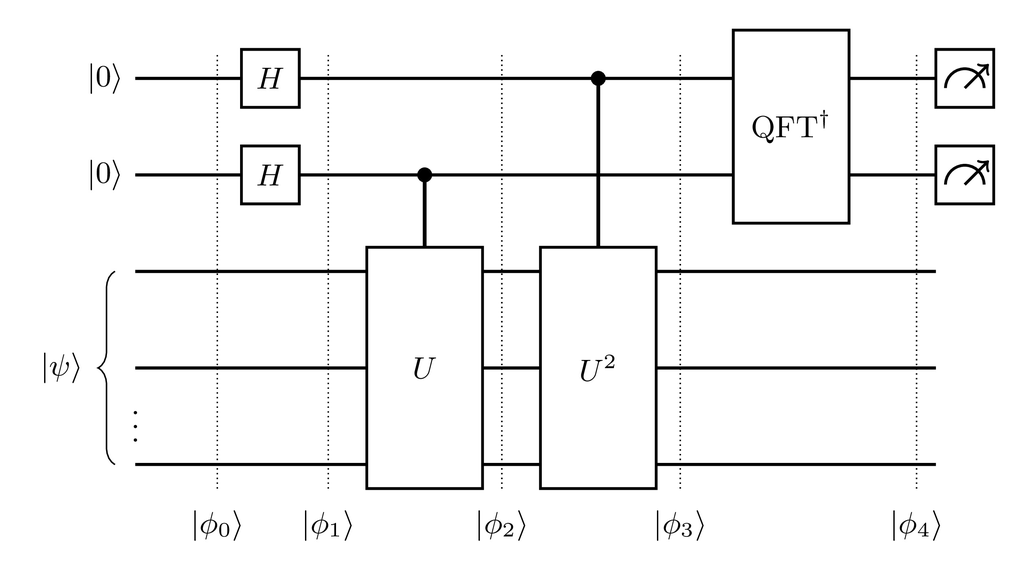

Previously, we had established:

$$ | \phi_{3} \rangle = \frac{1}{2} \left[ |00 \rangle + e^{2 \pi i \theta} |01 \rangle + e^{4 \pi i \theta} |10 \rangle + e^{6 \pi i \theta} |11\rangle \right] \otimes | \psi \rangle $$

After applying the $\QFT^{\textdagger}$, we have:

$$ \begin{aligned} | \phi_4 \rangle &= \QFT^{\textdagger} \left( \frac{1}{2} \sum\limits_{m=0}^3 e^{2 \pi i \theta m} | m \rangle \right) \otimes | \psi \rangle \\ &= \frac{1}{2} \sum\limits_{m=0}^3 e^{2 \pi i \theta m} \QFT^{\textdagger} \left( | m \rangle \right) \otimes | \psi \rangle \\ &= \frac{1}{2} \sum\limits_{m=0}^3 \left( \frac{1}{2} \sum\limits_{j=0}^3 e^{2 \pi i \theta m} e^{-2 \pi i m \frac{j}{4}} \right) | j \rangle \otimes | \psi \rangle \\ &= \sum\limits_{j=0}^{3} \left( \frac{1}{4} \sum\limits_{m=0}^3 e^{2 \pi i m \left( \theta - \frac{ j}{4} \right)} \right) | j \rangle \otimes | \psi \rangle \end{aligned} $$ Define coefficients: $$ \alpha_j (\theta) = \frac{1}{4} \sum\limits_{m=0}^3 e^{2 \pi i m \left( \theta - \frac{ j }{ 4 } \right)}. $$

Thus, the final state can be written as:

$$ | \phi_4 \rangle = \sum\limits_{j=0}^3 \alpha_j (\theta) |j \rangle \otimes | \psi \rangle, $$ with the explicit amplitudes: $$ \begin{aligned} \alpha_0 (\theta) &= \frac{1}{4} \left( 1 + e^{2 \pi i \theta} + e^{4 \pi i \theta} + e^{6 \pi i \theta} \right) \\ \alpha_1 (\theta) &= \frac{1}{4} \left( 1 + e^{2 \pi i \left( \theta - \frac{1}{4} \right) } + e^{4 \pi i \left( \theta - \frac{1}{4} \right)} + e^{6 \pi i \left( \theta - \frac{1}{4} \right)} \right) \\ \alpha_2 (\theta) &= \frac{1}{4} \left( 1 + e^{2 \pi i \left( \theta - \frac{2}{4} \right) } + e^{4 \pi i \left( \theta - \frac{2}{4} \right)} + e^{6 \pi i \left( \theta - \frac{2}{4} \right)} \right) \\ \alpha_3 (\theta) &= \frac{1}{4} \left( 1 + e^{2 \pi i \left( \theta - \frac{3}{4} \right) } + e^{4 \pi i \left( \theta - \frac{3}{4} \right)} + e^{6 \pi i \left( \theta - \frac{3}{4} \right)} \right) \end{aligned} $$

To further simplify

$$ \alpha_{j}(\theta) = \tfrac{1}{4} \sum_{m=0}^3 e^{2 \pi i m \left( \theta - \tfrac{j}{4} \right)}, $$

we first recognize the summation as a finite geometric series:

$$ \alpha_j (\theta) = \tfrac{1}{4} \cdot \frac{1 - r^4}{1 - r}, \qquad r = e^{2 \pi i \left(\theta - \tfrac{j}{4}\right)}. $$

Using the identity

$$ 1 - e^{i \phi} = -2 i e^{i \phi/2} \sin \!\left(\tfrac{\phi}{2}\right), $$

and simplifying both numerator and denominator, we obtain

$$ \alpha_j(\theta) = \tfrac{1}{4}\, e^{3 \pi i \left( \theta - \tfrac{j}{4} \right)} \cdot \frac{\sin \!\left( 4 \pi \left( \theta - \tfrac{j}{4} \right) \right)}{\sin \!\left( \pi \left( \theta - \tfrac{j}{4} \right) \right)}. $$

A similar derivation is presented in the [Quantum Fourier Transform demo](https://sohrabganjian.github.io/blog/2025/quantum_fourier_transform/), with more intermediate steps.

Finally, the measurement probability is

$$ \big| \alpha_{j}(\theta) \big|^2 = \tfrac{1}{16} \left[ \frac{\sin \!\left( 4 \pi \left( \theta - \tfrac{j}{4} \right) \right)}{\sin \!\left( \pi \left( \theta - \tfrac{j}{4} \right) \right)} \right]^2, \qquad j \in \{0,1,2,3\}. $$

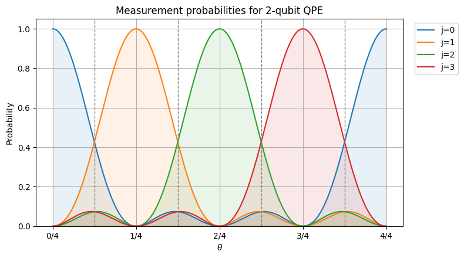

```python
# P(j|theta) = [ sin(pi*N*delta) / (N*sin(pi*delta)) ]^2
#            = [ sinc(N*delta) / sinc(delta) ]^2   where numpy's sinc(x) = sin(pi x)/(pi x)

def P_j_theta(theta, j, N=4):
    delta = theta - j / N
    num = np.sinc(N * delta)
    den = np.sinc(delta)
    ratio = np.divide(num, den, out=np.zeros_like(num), where=den!=0)
    return ratio**2

thetas = np.linspace(0, 1, 1000)
probs_stable = {j: P_j_theta(thetas, j) for j in range(4)}

plt.figure(figsize=(8, 4.5))
colors = ['tab:blue', 'tab:orange', 'tab:green', 'tab:red']
for j, color in zip(range(4), colors):
    plt.plot(thetas, probs_stable[j], color=color, label=f"j={j}")
    plt.fill_between(thetas, probs_stable[j], alpha=0.1, color=color)


# X ticks at m/4
N = 4
xticks = [m/N for m in range(N+1)]
plt.xticks(xticks, [f"{m}/4" for m in range(N+1)])

# Vertical dotted lines at midpoints (j+0.5)/N
for j in range(N):
    x = (j+0.5)/N
    plt.axvline(x, color="gray", linestyle="--", linewidth=1, alpha=1)


plt.title("Measurement probabilities for 2-qubit QPE")
plt.xlabel(r"$\theta$")
plt.ylabel("Probability")
plt.ylim(0, 1.05)
plt.legend(bbox_to_anchor=(1.02, 1), loc='upper left')

plt.tight_layout()
plt.grid(True)
plt.show()
```

Going back to the earlier example with 1-qubit QPE, $\theta = 0.82_{10} \approx 0.1101000111101011\ldots_2$, the algorithm is more likely to return $0$ than $0.5$, since $$ p(0)=\cos^2(\pi\theta)\approx 0.7129,\qquad p(1)=\sin^2(\pi\theta)\approx 0.2871, $$ even though the first binary digit of $0.82$ is $1$. However, the 2-qubit QPE returns an integer $m\in\{0,1,2,3\}$ with probability $$ p(m)=\frac{1}{16}\left(\frac{\sin(4\pi\delta_m)}{\sin(\pi\delta_m)}\right)^2,\qquad \delta_m=\theta-\frac{m}{4}. $$ For $\theta=0.82$, the values are:

| $m$ | $\delta_m=\theta-\tfrac{m}{4}$ | $p(m)$ |
| --- | --- | --- |
| 0 | $0.82$ | $0.129238\ldots$ |
| 1 | $0.57$ | $0.038960\ldots$ |
| 2 | $0.32$ | $0.052050\ldots$ |
| 3 | $0.07$ | $0.779752\ldots$ |

As we see, the most likely outcome is $m=3$, which in 2-bit fraction is $0.11$. This correctly captures the first two binary digits of $\theta$.

### $t$-qubit Phase Estimation

Having covered the one- and two-qubit phase estimations, we are now ready to generalize this to the $t$-qubit case, where the circuit is equipped with $t$ ancilla qubits. The algorithm proceeds as follows:

1. Prepare the input state $|0\rangle^{\otimes t} \otimes |\psi\rangle$.
2. Apply Hadamard gates to all $t$ ancilla qubits.
3. For each ancilla qubit $k$, with $0 \leq k \leq t-1$, apply a controlled-$U^{2^k}$ gate, where the $k$-th ancilla acts as control.
4. Apply the inverse quantum Fourier transform $\QFT^\dagger_{2^t}$ to the ancilla register.
5. Measure the $t$ ancilla qubits.

The outcome is, with high probability, the $t$-bit binary fraction $\frac{m}{2^t}$ that is closest to $\theta$, where $\theta$ is the phase of the eigenvalue of the unitary $U$: $$ U|\psi\rangle = \lambda |\psi\rangle, \qquad \lambda = e^{2\pi i \theta}, \quad 0 \leq \theta < 1. $$

If $\theta$ coincides exactly with such a fraction, the outcome aligns exactly with it.

The circuit visualization is shown in the figure below:

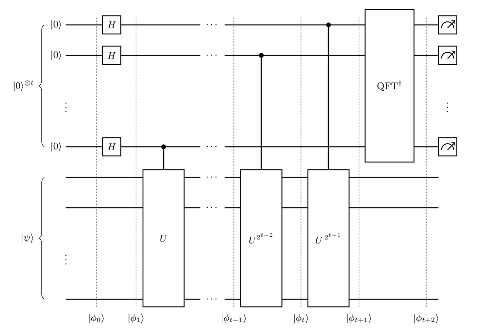

The evolution of the input state $|\phi_0\rangle = |0\rangle^{\otimes t}\otimes|\psi\rangle$ according to the 5-step algorithm is:

1. **Prepare** $$ |\phi_0\rangle = |0\rangle^{\otimes t}\otimes|\psi\rangle. $$
2. **Hadamards on ancillas** $$ |\phi_1\rangle = \frac{1}{\sqrt{N}}\sum_{m=0}^{N-1} |m\rangle\otimes|\psi\rangle = \frac{1}{\sqrt{N}}\sum_{b\in\{0,1\}^t} |b_{t-1}\cdots b_0\rangle\otimes|\psi\rangle, $$ where $N \coloneqq 2^t$.
3. **Controlled unitaries $U^{2^k}$, for $k=0,\ldots,t-1$.** After all $t$ controls: $$ |\phi_{t+1}\rangle = \frac{1}{\sqrt{N}}\sum_{m=0}^{N-1} e^{2\pi i \theta m}\,|m\rangle\otimes|\psi\rangle. $$
4. **Apply $\QFT_N^\dagger$ to ancillas.** Using $\QFT_N^\dagger|m\rangle=\frac{1}{\sqrt{N}}\sum\limits_{j=0}^{N-1}e^{-2\pi i j \frac{m}{N}}|j\rangle$: $$ |\phi_{t+2}\rangle = \sum_{j=0}^{N-1}\alpha_j(\theta)\,|j\rangle\otimes|\psi\rangle, \qquad \alpha_j(\theta)=\frac{1}{N}\sum_{m=0}^{N-1} e^{2\pi i m\left(\theta-\frac{j}{N}\right)}. $$

Its closed form is: $$ \alpha_j(\theta) = \frac{e^{\,i\pi (N-1)\left(\theta-\frac{j}{N}\right)}}{N}\, \frac{\sin\!\big(\pi N (\theta-\frac{j}{N})\big)}{\sin\!\big(\pi (\theta-\frac{j}{N})\big)}. $$

5. **Measure ancillas** $$ p(j\mid\theta) = \big|\alpha_j(\theta)\big|^2 = \frac{1}{N^{2}}\left[\frac{\sin\!\big(\pi N (\theta-\frac{j}{N})\big)}{\sin\!\big(\pi (\theta-\frac{j}{N})\big)}\right]^2. $$

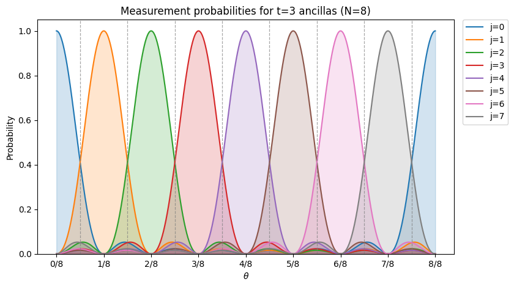

```python
def P_j_theta_general(theta, j, N):
    delta = theta - j / N
    num = np.sinc(N * delta)      # sin(pi*N*delta)/(pi*N*delta)
    den = np.sinc(delta)          # sin(pi*delta)/(pi*delta)
    ratio = np.divide(num, den, out=np.zeros_like(num), where=den!=0)
    return ratio**2               # This equals [sin(pi N delta)/(N sin(pi delta))]^2

def plot_qpe_probs(t=2, num_points=2001, show_bound=False, shade=True):
    N = 2**t
    thetas = np.linspace(0, 1, num_points)

    plt.figure(figsize=(8.5, 4.8))
    for j in range(N):
        pj = P_j_theta_general(thetas, j, N)
        line, = plt.plot(thetas, pj, label=f"j={j}")
        if shade:
            plt.fill_between(thetas, pj, alpha=0.2, color=line.get_color())

    # X ticks at m/N
    xticks = [m/N for m in range(N+1)]
    plt.xticks(xticks, [f"{m}/{N}" for m in range(N+1)])

    # Vertical dotted lines at midpoints (j+0.5)/N
    for j in range(N):
        x = (j + 0.5) / N
        plt.axvline(x, linestyle="--", linewidth=0.9, alpha=0.7, color="gray")

    if show_bound:
        bound = 4/np.pi**2 if N >= 2 else 1.0
        plt.axhline(bound, linestyle="--", linewidth=1.0, color="black", label=f"4/π² ≈ {bound:.3f}")

    plt.title(f"Measurement probabilities for t={t} ancillas (N={N})")
    plt.xlabel(r"$\theta$")
    plt.ylabel("Probability")
    plt.ylim(0, 1.05)
    plt.legend(bbox_to_anchor=(1.02, 1), loc='upper left', borderaxespad=0.)
    plt.tight_layout()
    plt.show()

plot_qpe_probs(t=3)
```

### Error Analysis

We have described how QPE works and analyzed its behavior in the general case. In particular, we have seen that when $\theta$ happens to be a binary fraction of the form $\theta = \tfrac{m}{2^n}$ with $0 \leq m \leq 2^n - 1$, the algorithm returns the exact value of $\theta$, provided a sufficient number of ancilla qubits are used. In practice, $\theta$ will almost always fall outside this special case, and so it is important to establish theoretical bounds on the accuracy of the algorithm in the general setting.

Theorem - Nearest-bin success probability.

Let $t \in \mathbb{N}$ and $N = 2^t$. In Quantum Phase Estimation with $t$ ancillas, the output register takes values $j \in \{0, \dots, N-1\}$ corresponding to binary fractions $\frac{j}{N}$. Define $$ m = \arg\min_{j \in \{0,1,\ldots, N-1 \}} \left| \theta - \frac{j}{N} \right|, $$ that is, $m = \mathrm{round}(N\theta)$, the nearest $t$-bit binary fraction to $\theta$. Then the probability of obtaining $m$ upon measurement satisfies $$ p(m) \geq \frac{4}{\pi^2} \approx 0.405, $$ with equality approached when $\theta$ lies halfway between two neighboring fractions $\frac{j}{N}$. If $\theta = \frac{s}{N}$ exactly, then $p(s) = 1$.

**Proof (click to expand / collapse)**

After the controlled unitaries and the inverse QFT on $t$ ancillas, the first register is $$ |\phi_{t+2}\rangle = \sum_{j=0}^{N-1} \alpha_j(\theta) |j\rangle,\qquad \alpha_j(\theta) = \frac{1}{N}\sum_{m=0}^{N-1}e^{2\pi i m\left(\theta-\tfrac{j}{N}\right)}. $$ Hence the measurement probabilities are $$ p(j)=|\alpha_j(\theta)|^2 = \frac{1}{N^2}\left[\frac{\sin \big(\pi N(\theta-\tfrac{j}{N})\big)}{\sin \big(\pi(\theta-\tfrac{j}{N})\big)}\right]^2. $$ Let $m=\mathrm{round}(N\theta)$ and define $$ \delta=\theta-\tfrac{m}{N} - \mathrm{round} \left( \theta-\tfrac{m}{N} \right), $$ so that $\delta \in \left[ -\tfrac{1}{2}, \tfrac{1}{2} \right]$. By construction, $\tfrac{m}{N}$ is the nearest grid point to $\theta$, so the $|\delta|$ difference always satisfies $$ |\delta| \le \tfrac{1}{2N}. $$ Note that if we had instead taken the crude difference $\delta_0=\theta-\tfrac{m}{N}$ without reduction, then near the endpoints of $[0,1)$ we could get values outside the intended range. For example, with $N=2$, $\theta=0.82$, $m=0$ gives $\delta_0=0.82$, which violates the $\tfrac{1}{2N}=0.25$ bound. Subtracting $\mathrm{round}(\delta_0)$ centers the difference in $[-\tfrac12,\tfrac12]$ and restores the guarantee $|\delta|\le 1/(2N)$.

Continuing the proof, we have $$ p(m )=\frac{1}{N^2}\left[\frac{\sin(\pi N\delta)}{\sin(\pi\delta)}\right]^2. $$

Next we want to find bounds for the numerator $\sin(\pi N \delta)$ and the denominator $\sin(\pi \delta)$. Since $\sin$ is an odd function, the ratio is even in $\delta$, so we may restrict our focus to $\sin(\pi N |\delta|)$ and $\sin(\pi |\delta|)$. Moreover, because we seek a lower bound on $p(m)$, we want to bound the numerator from below and the denominator from above. That is, we look for $\sin(\pi N |\delta|) \geq f(x)$ and $\sin(\pi |\delta|) \leq g(x)$ for suitable functions $f,g$.

Bounding $\sin(\pi |\delta|)$ is straightforward since $\sin(x) \leq x$ for all $x \geq 0$. This inequality follows, for example, from the Taylor expansion of $\sin(x)$.

For bounding $\sin(\pi N |\delta|)$ from below, define $h(x) = \frac{\sin(x)}{x}$ for $x>0$. Differentiating gives $h'(x) = \frac{x \cos(x) - \sin(x)}{x^2}$. Now, $$ \frac{d}{dx}\big(x \cos(x) - \sin(x)\big) = -x \sin(x) \le 0 \quad \text{for } x\in[0,\tfrac{\pi}{2}], $$ and since $x \cos(x) - \sin(x)=0$ at $x=0$, it follows that $x \cos(x) - \sin(x) \le 0$ on $[0,\frac{\pi}{2}]$. Hence $h'(x)\le 0$ there, so $h(x)$ is decreasing on $[0,\frac{\pi}{2}]$. Therefore $$ \frac{\sin(x)}{x} \geq \frac{\sin(\pi/2)}{\pi/2} = \frac{2}{\pi}, \qquad x\in \left[0,\frac{\pi}{2}\right]. $$ This implies $\sin(x) \geq \tfrac{2}{\pi} x$ on $[0,\frac{\pi}{2}]$.

Recall $0 \le \pi N|\delta| \le \frac{\pi}{2}$ since $|\delta|\le \frac{1}{2N}$. Applying the above inequality with $x=\pi N|\delta|$ gives $$ \sin(\pi N |\delta|) \geq \frac{2}{\pi} \pi N |\delta| = 2 N |\delta|. $$

Finally, putting everything together, $$ \begin{aligned} p(m) &= \frac{1}{N^2}\left[\frac{\sin(\pi N\delta)}{\sin(\pi\delta)}\right]^2 \\ &\geq \frac{1}{N^2} \left[ \frac{2 N |\delta|}{\pi |\delta|} \right]^2 \\ &= \frac{4}{\pi^2}. \end{aligned} $$

If $\delta=0$, that is $\theta=\frac{s}{N}$, then $\sin(\pi N\delta)=0$ and the geometric sum gives $\alpha_s=1$, $\alpha_{j\ne s}=0$, so $p(s)=1$.

Lastly, when $|\delta|=\frac{1}{2N}$, that is at the midpoint between bins, we have

$$ \begin{aligned} p(m) &= \frac{1}{N^2} \left[ \frac{\sin\left( \pi N \cdot \frac{1}{2N} \right)}{\sin\left( \pi \cdot \frac{1}{2N} \right)} \right]^2 \\[6pt] &= \frac{1}{N^2} \left[ \frac{\sin\left( \frac{\pi}{2} \right)}{\sin\left( \frac{\pi}{2N} \right)} \right]^2 \\[6pt] &= \frac{1}{N^2 \sin^2\left( \frac{\pi}{2N} \right)}. \end{aligned} $$

As $N \to \infty$, we have $\frac{\pi}{2N} \to 0$ and $\sin\!\left(\frac{\pi}{2N}\right) \sim \frac{\pi}{2N}$. Therefore

$$ N^2 \sin^2\left(\frac{\pi}{2N}\right) \sim N^2 \left(\frac{\pi}{2N}\right)^2 = \frac{\pi^2}{4}, $$

so

$$ p(m) \sim \frac{4}{\pi^2}. $$

Thus, while for finite $N$ the probability is slightly larger than $\frac{4}{\pi^2}$, as $N$ grows it approaches $\frac{4}{\pi^2}$ from above. This shows that $\frac{4}{\pi^2}$ is the best universal lower bound.

While we have proven that the probability of obtaining the nearest bin to the $t$-bit binary expansion of $\theta$ is at least $40\%$, note that this is not the same as correctly outputting the most significant bit with probability greater than $40\%$.

For example, when $\theta = 0.82$ and we run 1-bit QPE, the algorithm assigns about $71\%$ probability to outcome $0$, which is the nearest bin according to the theorem. However, the correct most significant bit of $\theta$ is $1$, and that outcome has probability only about $29\%$. This does not contradict the theorem: the guarantee concerns the nearest bin, not any individual bit.

The success probability for the most significant bits can be increased to any desired confidence level by introducing additional ancillas and discarding the least significant bits. We formalize this in the next theorem, and provide a sketch proof of the argument. For full details, see Section 5.2 of Nielsen and Chuang, and the paper *Tight Bounds for Quantum Phase Estimation and Related Problems* by Nikhil S. Mande and Ronald de Wolf ([arXiv:2305.04908](https://arxiv.org/abs/2305.04908)).

Theorem - QPE $\epsilon-\Delta$ bound.

Let $U |\psi \rangle = e^{2 \pi i \theta} | \psi \rangle$ with $\theta \in [0,1)$. Fix additive error $\epsilon > 0$ and failure probability $\Delta \in (0,1)$. There exists a phase-estimation procedure that outputs $\tilde\theta$ with $$ |\tilde\theta - \theta| \leq \epsilon \qquad \text{with probability at least } 1 - \Delta $$ using a total of $$ \mathcal{O} \left( \frac{ \log \left( \frac{1}{\Delta} \right) }{ \epsilon } \right) $$ uses of controlled-$U$ (counting $U^{2^j}$ as $2^j$ uses) and $\mathcal{O} \left( \log \left( \frac{1}{\epsilon} \right) \right) $ ancilla qubits.

Remarks

1. **Additive error**  
   *Additive error* means, in this context, we guarantee

   $$ \lvert \tilde{\theta} - \theta \rvert \leq \epsilon. $$

   That is, the estimate is within a fixed interval of width $\epsilon$, independent of the size of $\theta$.

   On the other hand, *multiplicative error* means

   $$ \lvert \tilde{\theta} - \theta \rvert \leq \epsilon \, \lvert \theta \rvert, $$

   so the error allowed scales with the magnitude of the true value.
2. **Controlled-$U$ Count**

In the black-box model, the input is a unitary $U$ with the eigenstate $\lvert \psi \rangle$, and we assume that we can perform controlled-$U$ operations as a given.

In practice, a QPE circuit uses powers $U^{2^j}$. These appear as $t$ controlled-$U^{2^j}$ blocks. In query complexity, each call to $U$ is one query. Thus, implementing $U^{2^j}$ requires $2^j$ such queries. We count the number of actual $U$ calls needed to implement those blocks:

$$ 1 + 2 + \dots + 2^{t-1} = 2^t - 1 \sim \mathcal{O}(2^t). $$

Later, we will relate $t$ to the target accuracy $\epsilon$, which shows how the exponential-in-$t$ cost translates into a $\frac{1}{\epsilon}$ scaling for query complexity, while the number of ancillas grows only logarithmically in $\frac{1}{\epsilon}$.

3. **Types of complexities in QPE**
- **Query complexity:** The total number of applications of $U$ across all runs.

  With accuracy $\epsilon$ and confidence $1-\Delta$, the cost is
  $$ \mathcal{O} \left(\frac{\log \left( \frac{1}{\Delta} \right)}{\epsilon}\right). $$
- **Ancilla complexity:** The number of qubits required in the phase register.

  To achieve $\epsilon$-precision we need
  $$ \mathcal{O} \left(\log\left(\frac{1}{\epsilon}\right) \right). $$
- **Gate complexity (excluding $U$):** The number of elementary gates such as Hadamards, controlled phase rotations, and the inverse QFT.

  For $t = \mathcal{O}\left(\log\left(\frac{1}{\epsilon}\right)\right)$ ancillas, the naive inverse QFT requires
  $$ \mathcal{O}\left(\left(\log\left(\frac{1}{\epsilon}\right)\right)^2\right) $$
  gates. With an approximate QFT, this can be reduced to
  $$ \mathcal{O}\left(\log\left(\frac{1}{\epsilon}\right)\,\log\left(\log\left(\frac{1}{\epsilon}\right)\right)\right). $$

  Note: Among these, the query complexity dominates. The dependence on $\frac{1}{\epsilon}$ (and $\log\left(\frac{1}{\Delta}\right)$) is far more costly than the logarithmic overhead from ancillas or the polynomial-logarithmic cost of the QFT gates.
4. **Median Trick**

In the proof we will want to argue that if each independent run of the algorithm is more likely to be correct than incorrect, then repeating the algorithm many times and taking a representative outcome should yield a reliable result.  
The median of the runs is a natural choice, because if a strict majority of the outcomes fall inside a target interval, then the median must also lie inside that interval.  
This is the basic idea behind the so-called *[median trick](https://en.wikipedia.org/wiki/Median_trick)*.

**Statement**

Let $x_1,\dots,x_R$ be real numbers. If more than $\frac{R}{2}$ of them lie inside an interval $I$, then the median of the $x_i$ also lies inside $I$.  
This fact allows us to combine multiple independent trials into one robust estimate.

5. **Chernoff-Hoeffding bound**

In the proof we will need to argue that if each run of the algorithm succeeds with probability strictly greater than $\tfrac{1}{2}$, then when we repeat the procedure many times the total number of successful runs will, with high probability, also be greater than $\tfrac{R}{2}$.

The Chernoff-Hoeffding) bound formalizes this: it shows that the probability of the number of successes falling below half decreases exponentially fast as the number of repetitions $R$ grows.

This ensures that with high probability a strict majority of the runs succeed, which justifies taking the median of the outcomes as the final estimate.

**Statement**

Let $X_1,\dots,X_R$ be independent Bernoulli random variables with $\mathbb{P}[X_i=1]=p$ and $\mathbb{P}[X_i=0]=1-p$, where $0<p<1$.
Let $S=\sum_{i=1}^R X_i$ and $\mu=\mathbb{E}[S]=pR$.
Then for any $\delta\in(0,1)$, $$ \mathbb{P}\left(S \le (1-\delta)\mu\right) \le \exp\left(-\frac{\delta^2\mu}{2}\right). $$

Intuitively, if each trial is more likely to succeed than fail, the probability that the majority fail decreases exponentially fast with the number of repetitions $R$. This is what allows us to amplify the success probability by repeating the algorithm and taking a majority or median.

6. **Asymptotic notation**

We use three related asymptotic symbols to describe growth rates of functions $f(n)$ and $g(n)$, where $g(n) > 0$ for all sufficiently large $n$:

- $\mathcal{O}$ (upper bound):
  $$ f(n) = \mathcal{O}(g(n)) \quad \iff \quad \exists C > 0, n_0 \text{ such that } 0 \le f(n) \le C g(n), \forall n \ge n_0 $$
- $\Omega$ (lower bound):
  $$ f(n) = \Omega(g(n)) \quad \iff \quad \exists C > 0, n_0 \text{ such that } f(n) \ge C g(n), \forall n \ge n_0 $$
- $\Theta$ (tight bound):
  $$ f(n) = \Theta(g(n)) \quad \iff \quad \exists C_1, C_2 > 0, n_0 \text{ such that } C_1 g(n) \le f(n) \le C_2 g(n), \forall n \ge n_0 $$

The notation $\mathcal{O}(g(n))$ only gives an upper bound, asserting that $f$ does not grow faster than $g$ beyond constants. The notation $\Omega(g(n))$ only gives a lower bound, asserting that $f$ does not grow slower than $g$. Using $\Theta(g(n))$ instead of $\mathcal{O}(g(n))$ or $\Omega(g(n))$ is stronger, because it asserts both an upper and a lower bound on the growth rate.

7. **Optimality of the Bound**

Mande and de Wolf ([arXiv:2305.04908](https://arxiv.org/abs/2305.04908)) proved a matching lower bound showing that any phase estimation algorithm with additive error $\epsilon$ and failure probability $\Delta$ requires at least $$ \Omega \left(\frac{1}{\epsilon}\log\frac{1}{\Delta}\right) $$ queries. Combined with the constructive upper bound from QPE with amplification, this gives the tight characterization $$ \Theta \left(\frac{1}{\epsilon}\log\frac{1}{\Delta}\right). $$

**Proof Sketch (click to expand / collapse)**

1. **$\epsilon$-accuracy.**

Let $$ n = \left\lceil \log_2\left( \frac{1}{\epsilon} \right) \right\rceil. $$ If we can recover the first $n$ binary digits of $\theta$, then $$ \left| \tilde{\theta} - \theta \right| \le 2^{-n} \le \epsilon. $$

We define $\epsilon$-accurate as an estimate $\tilde\theta$ such that $\left| \tilde\theta - \theta \right| \leq \epsilon$.

2. **Single run of the QPE algorithm.**

Use $t = n + p$ ancillas for some small constant $p$.
After applying the controlled powers $U^{2^0}, U^{2^1}, \dots, U^{2^{t-1}}$ and the inverse QFT, the probability of outcome $m$ is $$ p(m) = \frac{1}{2^{2t}} \cdot \frac{\sin^2\left( \pi \, 2^t \left( \theta - \frac{m}{2^t} \right) \right)}{\sin^2\left( \pi \left( \theta - \frac{m}{2^t} \right) \right)}. $$ Let $b = \operatorname{round}(2^t \theta)$ be the nearest integer to $2^t\theta$.
Introduce a radius parameter $r$. A geometric-series estimate of the Fourier sum gives $$ \Pr\left( \left| m - b \right| > r \right) \le \frac{1}{2\left(r-1\right)}. $$ Thus, the $n$ most significant bits of $m$ are correct with probability at least $1 - 2^{-(p-1)}$ if we take $r = 2^{p-1}$.
For instance, with $p=2$ this probability is at least $\frac{1}{2}$, and with $p=3$ it is at least $\frac{3}{4}$.

Note the tail bound used here requires a radius $r>1$. With $r=2^{p-1}$ this means $p \geq 2$.

Cost of one run:
The controlled powers require $$ 1 + 2 + \cdots + 2^{t-1} = 2^t - 1 = \mathcal{O}\left(2^n\right) = \mathcal{O}\left(\frac{1}{\epsilon}\right) $$ applications of $U$.
The ancilla cost is $t = n + p = \mathcal{O}\left(\log\left( \frac{1}{\epsilon}\right)\right)$.

3. **Amplifying the success probability.**

Repeat the procedure independently $R$ times to obtain estimates $\tilde{\theta}_1,\dots,\tilde{\theta}_R$, and return the median.

Define $$ X_i = \mathbf{1}\{|\tilde{\theta}_i - \theta| \le \epsilon\}, \qquad S = \sum_{i=1}^{R} X_i. $$ From Step 2, when $p \ge 2$ the per-run success probability satisfies $$ p_{\text{succ}} = \mathbb{P}[X_i=1] \ge 1 - 2^{-(p-1)} > \frac{1}{2}. $$ Hence $$ \mu = \mathbb{E}[S] = p_{\text{succ}} R > \frac{R}{2}. $$

We bound the event $S \le \frac{R}{2}$ using a Chernoff–Hoeffding lower-tail inequality: $$ \mathbb{P}\left( S \le (1-\delta)\mu \right) \le \exp\left( -\frac{\delta^{2}\mu}{2} \right). $$ Set $(1-\delta)\mu = \frac{R}{2}$, which gives $$ \delta = 1 - \frac{R}{2\mu} = 1 - \frac{1}{2 p_{\text{succ}}}. $$ Substituting $\mu = p_{\text{succ}} R$ yields $$ \mathbb{P}\left( S \le \frac{R}{2} \right) \le \exp\left( -\frac{p_{\text{succ}}}{2}\left(1 - \frac{1}{2 p_{\text{succ}}}\right)^{2} R \right). $$

The factor in the exponent depends only on $p_{\text{succ}}$ and is strictly positive whenever $p_{\text{succ}} > \frac{1}{2}$.
For readability, denote $$ c = \frac{p_{\text{succ}}}{2}\left(1 - \frac{1}{2 p_{\text{succ}}}\right)^{2}, $$ so that $$ \mathbb{P}\left( S \le \frac{R}{2} \right) \le \exp(-c R). $$

Choosing $$ R = \left\lceil \frac{1}{c}\,\log\left(\frac{1}{\Delta}\right) \right\rceil = \Theta\left( \log\left(\frac{1}{\Delta}\right) \right) $$ ensures $\mathbb{P}\left( S \le \frac{R}{2} \right) \le \Delta$.
Here $\Delta$ is the tolerated failure probability and $1-\Delta$ is the confidence.
Smaller $\Delta$ means higher confidence and requires more repetitions $R$, while larger $\Delta$ means lower confidence and fewer repetitions.

By the median trick (see Remark), if $S > \frac{R}{2}$ then the median of $\tilde{\theta}_1,\dots,\tilde{\theta}_R$ lies in $[\theta-\epsilon,\theta+\epsilon]$. Thus with probability at least $1-\Delta$, the returned median is $\epsilon$-accurate.

4. **Complexity summary.**

Per run, the number of applications of $U$ is $$ \mathcal{O}\left(\frac{1}{\epsilon}\right), $$ and the ancilla count is $$ t = n+p = \mathcal{O}\left(\log\frac{1}{\epsilon}\right), \qquad p \geq 2 $$ With $R=\Theta\left(\log\left(\frac{1}{\Delta}\right)\right)$ independent repetitions, the total query complexity is $$ \mathcal{O}\left(\frac{\log\left(1/\Delta\right)}{\epsilon}\right). $$

The additional gate complexity (excluding calls to $U$) is polylogarithmic in $1/\epsilon$ and dominated by the query cost.

### Example: Estimating a Phase with QPE

Having introduced the QPE algorithm and its error analysis, we will now implement a simple QPE circuit in PennyLane and see how we can estimate $\theta$ through a small example.

In this example, we attempt to estimate the phase of a unitary $U$ with eigenphase parameter $\theta = 0.82$, whose binary representation is $0.1101000111101011\ldots_2$. Up to two bits of precision, we expect the outcome $\theta \approx 0.11_2 = 0.75$.

We will first explain how to set up the unitary and its eigenstate in a way that generalizes to any desired $\theta$. Then we will implement a QPE circuit in PennyLane to recover the first two bits of $\theta$. Finally, we will interpret the measurement results and show how to read off the estimated binary fraction.

**Preparing the unitary and eigenstate**

We need a unitary $U$ and an eigenstate $|\psi\rangle$ such that $$ U |\psi\rangle = e^{2\pi i \theta} |\psi\rangle, \qquad \theta = 0.82. $$

Use a 1-qubit phase shift on a target wire: $$ U(\theta) = \mathrm{diag}\big(1, e^{i\phi}\big), \quad \phi = 2\pi\theta. $$ Then $|1\rangle$ is an eigenstate with eigenvalue $e^{i\phi}=e^{2\pi i\theta}$. This works for any desired $\theta$; by setting $\phi=2\pi\theta$.

**In PennyLane**

- Prepare the target eigenstate $|1\rangle$ with `qml.X(target)`.
- Define the unitary as `qml.PhaseShift(2*np.pi*theta, wires=target)`.

```python
import pennylane as qml

theta = 0.82
phi = 2 * np.pi * theta

dev = qml.device("default.qubit", wires=1)

@qml.qnode(dev)
def prepare_eigenstate_and_apply_U():
    target = 0

    # |1> is an eigenstate of PhaseShift(phi)
    qml.X(target)

    # U |1> = e^{i phi} |1>
    qml.PhaseShift(phi, wires=target)

    return qml.state()
```

Next, we implement the QPE circuit, sample measurement outcomes over a specified number of shots, and collect statistics for analysis.

```python
# ----- problem setup -----
theta = 0.82
phi = 2 * np.pi * theta

t = 2                     # number of estimation qubits
phase_est_wires = list(range(t))      # estimation wires: [0, 1]
target = t                # target wire index: 2
N = 2**t

dev = qml.device("default.qubit", wires=t+1, shots=1000)

# Base unitary U = diag(1, e^{i phi}) acting on the target (|1> is eigenstate)
unitary = qml.PhaseShift(phi, wires=target)

@qml.qnode(dev)
def qpe_circuit():
    # Prepare the eigenstate |1> on the target
    qml.X(target)

    # Hadamards on estimation register
    for w in phase_est_wires:
        qml.Hadamard(w)

    # Controlled powers U^{2^{k}} with decreasing powers of 2 (handled by ControlledSequence)
    qml.ControlledSequence(base=unitary, control=phase_est_wires)

    # Inverse QFT on the estimation register
    qml.adjoint(qml.QFT)(wires=phase_est_wires)

    # Measure the estimation register (MSB is est[0], LSB is est[-1])
    return qml.sample(wires=phase_est_wires)
```

So far we have implemented the QPE circuit. Let’s draw it and check that it matches the expected structure: a layer of Hadamards, followed by controlled applications of the unitary, then the $\QFT^\dagger$, and finally measurement.

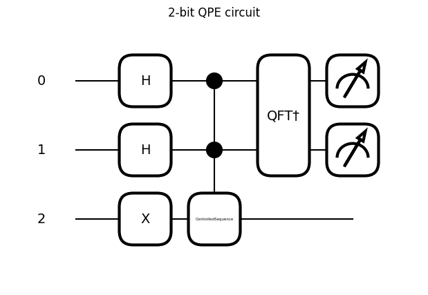

```python
fig, ax = qml.draw_mpl(qpe_circuit)()
fig.suptitle("2-bit QPE circuit", y=1.02)
plt.show()
```

The circuit diagram matches our expectations. While the `ControlledSequence` block is not expanded in the visualization, it indeed applies the correct controlled powers of $U$ as required by QPE. For details, see the [documentation](https://docs.pennylane.ai/en/stable/code/api/pennylane.ControlledSequence.html).

Now we will run the circuit and extract the output distribution to see how the measurement outcomes are distributed across the two estimation qubits.

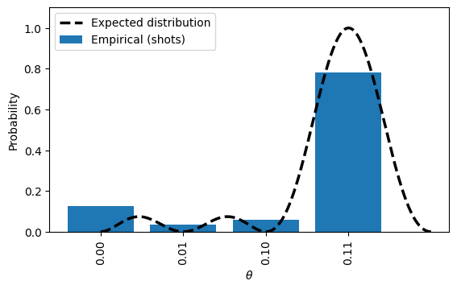

```python
from collections import Counter

shots = qpe_circuit()

# convert each row into a bitstring "01", "10", etc.
bitstrings = ["".join(str(b) for b in row) for row in shots]

# count occurrences
counts = Counter(bitstrings)

# normalize to probabilities
probs = {k: v/len(bitstrings) for k, v in counts.items()}

# sort by binary value for consistent order
sorted_items = sorted(probs.items(), key=lambda kv: int(kv[0], 2))
labels, values = zip(*sorted_items)

# map to "0.xx" style labels
labels = [f"0.{bs}" for bs in labels]

def P_j_theta(theta, j, N):
    delta = theta - j / N
    num = np.sinc(N * delta)
    den = np.sinc(delta)
    ratio = np.divide(num, den, out=np.zeros_like(num), where=den != 0)
    return ratio**2

# --- plotting ---
plt.bar(labels, values, label="Empirical (shots)")
plt.xlabel(r"$\theta$")
plt.ylabel("Probability")

plt.ylim(0, 1.1)
plt.yticks(np.arange(0, 1.01, 0.2))

N = len(labels)
theta = 0.82
m_star = int(round(theta * N))

x_grid = np.linspace(0, N, 2001, endpoint=False)   # stretched scale
p_kernel = P_j_theta(x_grid / N, m_star, N)

plt.plot(np.linspace(0, N, len(p_kernel)),
         p_kernel,
         linestyle="--",
         linewidth=2.5,
         color="black",
         label="Expected distribution")

plt.xticks(ticks=np.arange(N), labels=labels, rotation=90)
plt.subplots_adjust(bottom=0.3)

plt.legend()
plt.show()
```

```python
print(sorted_items)
```

```
[('00', 0.124), ('01', 0.036), ('10', 0.06), ('11', 0.78)]
```

We observe, as expected, that the bit string $11$ is the most likely outcome. The distribution matches the theoretical prediction and the experimental results. According to the QPE circuit, the two estimated bits of the phase fraction for $\theta = 0.82_{10} \approx 0.1101000111101011\ldots_2$ are $11$, which is correct. To achieve higher accuracy, one can use more qubits in the phase register, and to increase confidence, additional ancilla qubits can be employed as described in the error analysis methods above.

### Conclusion

In this tutorial on quantum phase estimation, we stated the phase estimation problem and connected the unitary operator $U$ with its eigenvalues and eigenstates through the spectral theorem. We began by analyzing the 1-qubit QPE circuit, then extended it to the 2-qubit case where we derived $\QFT^\dagger$ as a key circuit component, and finally generalized the construction to a $t$-qubit register. Next, we performed an error analysis of the QPE circuit and observed that the algorithm returns the bit string corresponding to the nearest $t$-bit approximation of $\theta$ with at least $40\%$ success probability. By introducing additional ancillary qubits and repeated measurements, we showed that this success probability can be boosted to arbitrary confidence, achieving precision $\epsilon$ and confidence $1-\Delta$ with query complexity $$ \mathcal{O}\!\left(\frac{\log(1/\Delta)}{\epsilon}\right). $$ Finally, we demonstrated an example QPE implementation in PennyLane, including state preparation, circuit construction, and interpretation of the measurement outcomes.

It must be noted that QPE is mathematically and probabilistically intensive, drawing on tools such as linear algebra, the spectral theorem, the median trick, the Chernoff–Hoeffding bound, Dirichlet- and Fejér-type kernels, and the quantum Fourier transform as an important subroutine. These tools are not only essential for constructing the algorithm but also for interpreting its output and analyzing its resource requirements.

While QPE is a robust and foundational quantum algorithm, it is resource-intensive and generally not considered NISQ-friendly for real-world applications. A direct comparison with classical algorithms is not straightforward, since classical costs are typically expressed in terms of the matrix dimension $N$, ranging between $\mathcal{O}(N^2)$ and $\mathcal{O}(N^3)$, whereas quantum costs are measured in terms of the target precision $\epsilon$ and are dominated by the $\mathcal{O}\!\left(\frac{1}{\epsilon}\right)$ scaling, with additional logarithmic dependence on the desired confidence level. Thus, the two settings measure computational cost in different variables. However, when $U$ has a structured form, such as in Shor’s algorithm, QPE can provide an exponential speedup over its best classical counterpart.

While this tutorial focused on the textbook version of QPE, there exist several important variants, such as [the iterative QPE introduced by Alexei Kitaev](https://arxiv.org/abs/quant-ph/9511026) and [Bayesian QPE approaches](https://link.aps.org/doi/10.1103/PhysRevResearch.6.013221). Some of these variants are more NISQ-friendly than others, though they introduce trade-offs, such as increased classical post-processing or probabilistic measurement outcomes.

In short, QPE is a powerful quantum algorithm that enables many of the most interesting and impactful applications of quantum computing, including quantum chemistry and, most famously, Shor’s algorithm.

## Appendix

### Appendix 1: Biography

While the introduction of quantum phase estimation (QPE) as a subroutine was already implicit in Shor's algorithm, without being explicitly named, the quantum computing community generally attributes the first formal introduction of the QPE algorithm to Alexei Kitaev's paper, published in [November 1995 on arXiv](https://arxiv.org/abs/quant-ph/9511026). Although the textbook version of QPE differs slightly from Kitaev's original formulation, his work laid the foundational principles of phase estimation as we understand it today.

For a discussion on the chronology of the QPE's discovery, see this post on [Quantum Computing Stack Exchange](https://quantumcomputing.stackexchange.com/questions/25647/chronology-of-discovery-of-quantum-phase-estimation-algorithm).

Alexei Kitaev, born in 1963 in what is now Russia, is a theoretical physicist best known for his groundbreaking contributions to quantum computation and condensed-matter theory. He earned his degrees at the Moscow Institute of Physics and Technology and completed his Ph.D. at the Landau Institute for Theoretical Physics in 1989. Kitaev subsequently worked as a researcher at the Landau Institute, at Microsoft Research, and later became a professor at Caltech.

Beyond developing the quantum phase estimation framework, Kitaev has made contributions to other areas of quantum science, including topological quantum computing and the Kitaev chain model of topological superconductors, the Abelian stabilizer framework and quantum error correction.

He has received numerous prestigious honours, including the

- [Breakthrough Prize in Fundamental Physics (2012)](https://breakthroughprize.org/Laureates/1/P1/Y2012)
- [Dirac Medal (2015)](https://www.ictp.it/home/dirac-medallists-2015)  
  and was elected to the
- [U.S. National Academy of Sciences (2021)](https://www.nasonline.org/news/national-academy-of-sciences-elects-new-members-including-a-record-number-of-women-and-international-members/).

### Appendix 2: References and Suggested Readings

1. IBM. *Phase Estimation and Factoring - Fundamentals of Quantum Algorithms.* Available at: https://quantum.cloud.ibm.com/learning/en/courses/fundamentals-of-quantum-algorithms/phase-estimation-and-factoring/introduction.
2. Nielsen, Michael A. & Chuang, Isaac L. (2010). *Quantum Computation and Quantum Information* (10th Anniversary Edition), Section 5.2: Phase estimation.
3. LaRose, Ryan (2019). *The Phase Estimation Algorithm (QuIC Seminar 4).* Available at: https://www.ryanlarose.com/uploads/1/1/5/8/115879647/quic03-phase-estimation.pdf.
4. Arrazola, Juan Miguel & Alonso, Guillermo (2024). *Intro to Quantum Phase Estimation.* PennyLane Demos. Available at: https://pennylane.ai/qml/demos/tutorial_qpe.
5. Kaye, Phillip; Laflamme, Raymond; Mosca, Michele (2006). *An Introduction to Quantum Computing.* Oxford University Press.
6. University of Cambridge (2019–2020). *Quantum Computing - Lecture 9: Quantum Fourier Transform & Quantum Phase Estimation.* Available at: https://www.cl.cam.ac.uk/teaching/1920/QuantComp/Quantum_Computing_Lecture_9.pdf.
7. Mitzenmacher, Michael & Upfal, Eli (2005). *Probability and Computing: Randomized Algorithms and Probabilistic Analysis.* Cambridge University Press.
8. Mande, Nikhil S. & de Wolf, Ronald (2023). *Tight Bounds for Quantum Phase Estimation and Related Problems.* [arXiv:2305.04908](https://arxiv.org/abs/2305.04908).
9. Kitaev, Alexei Yu. (1995). *Quantum Measurements and the Abelian Stabilizer Problem.* [arXiv:quant-ph/9511026](https://arxiv.org/abs/quant-ph/9511026).
10. Yamamoto, Kentaro; Duffield, Samuel; Kikuchi, Yuta; and Muñoz Ramo, David (2024). *Demonstrating Bayesian Quantum Phase Estimation with Quantum Error Detection.* Physical Review Research. https://journals.aps.org/prresearch/abstract/10.1103/PhysRevResearch.6.013221.
11. Ferris, Kaelyn (2023). *Iterative Quantum Phase Estimation: Moving Beyond Traditional QPE.* Qiskit Global Summer School 2023. YouTube. Available at: https://www.youtube.com/watch?v=aLSM0_H8hUE.

[1] A radix point is a general term for the symbol that separates the integer part of a number from its fractional part in any number base, though it is most commonly known as the decimal point when used in the base-10 (decimal) system.